[figure not shown]

# LINEAIRE REGRESSIE - TOEPASSING TRENDLIJN - DE POST

In deze notebook krijg je data voorgeschoteld van de Belgische postbedeling.  
- Je bepaalt de mate van samenhang a.d.h.v. de correlatiecoëfficiënt.  
- Je bepaalt de vergelijking van de regressielijn.  
- Je stelt de gegeven data en de regressielijn duidelijk voor op een grafiek.

### Opdracht

In de figuur zie je dat het aantal brieven dat een Belg per jaar verstuurt, sterk gedaald is in de periode 2010-2015. Het aantal verstuurde brieven kent dus een **dalende trend**. Het heeft ertoe geleid dat de postbode niet meer dagelijks je brieven bezorgt.

Je bekijkt het aantal verstuurde brieven per Belg per jaar in functie van het jaartal.  
Haal de data die je nodig hebt uit de figuur. Geef de data in als volgt:

- de x-waarden komen overeen met het jaartal;
- de y-waarden komen overeen met het aantal brieven per Belg per jaar.

Let op de verwoording '**in functie van**'! Daaruit leid je af welke grootheid op de x-as en welke op de y-as komt.

Tot slot stel je de gegeven data en de trendlijn duidelijk voor op een grafiek.

Tip: Je kan de voorstelling van de trendlijn verbeteren door extra x-waarden te gebruiken. Zo kan je meegeven hoe de cijfers in de toekomst mogelijk zullen evolueren. Met zo'n trendlijn stel je eigenlijk een wiskundig model op dat je toelaat mogelijke evoluties te bestuderen.

Vergeet niet om de nodige modules te importeren.

[figure not shown]

Figuur 1: Postbode komt niet meer elke dag aan huis. [1]

Ga stap voor stap te werk:

- importeer de nodige modules;
- geef de data in;
- visualiseer de data in een spreidingsdiagram;
- bereken de correlatiecoëfficiënt;
- geef de zelfgedefinieerde functies in die je nodig hebt voor de lineaire regressie;
- laat de coëfficiënten berekenen van de trendlijn;
- laat de y-waarden berekenen van de punten gelegen op de trendlijn;
- teken de trendlijn erbij op het spreidingsdiagram;
- gebruik extra x-waarden om de trend naar de toekomst toe te visualiseren.

In een andere notebook "LineaireRegressieOefeningPostpakken' krijg je de volgende twee opdrachten te vervullen:  
- Doe hetzelfde voor het aantal postpakken dat een Belg jaarlijks verstuurt.  
- Tussen welke grootheden is er het meeste samenhang: tussen het aantal brieven en het jaartal of tussen het aantal postpakken en het jaartal?

# Voorbeeldoplossing

### Nodige modules importeren

```python
import numpy as np
import matplotlib.pyplot as plt
import pandas as pd

from scipy.optimize import curve_fit
```

## 1. Data ingeven en visualiseren

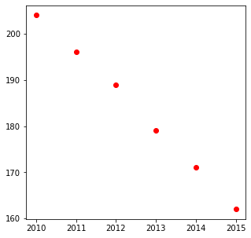

```python
x = np.array([2010, 2011, 2012, 2013, 2014, 2015])
y = np.array([204, 196, 189, 179, 171, 162])

plt.figure(figsize=(5, 5))

plt.scatter(x, y, color="red")

plt.show()
```

## 2. De correlatiecoëfficiënt

```python
np.corrcoef(x, y)[0,1]
```

```
-0.9990819895936358
```

Interpretatie:

De lineaire samenhang is zeer hoog omdat de coefficient dicht bij -1 ligt.

## 3. Lineaire regressie

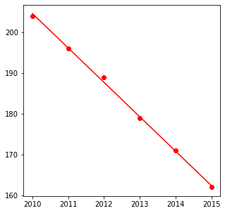

```python
def rechte(x, a, b):
    return a * x + b


def linreg(x, y):
    popt, pcov = curve_fit(rechte, x, y)

    a, b = popt
    return a, b

a, b = linreg(x, y)

plt.figure(figsize=(5, 5))

plt.scatter(x, y, color="red")
plt.plot(x, rechte(x, a, b), color="red")

plt.show()
```

## 4. Grafiek

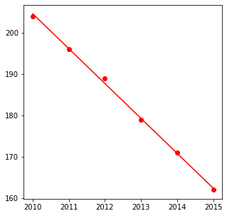

```python
plt.figure(figsize=(5, 5))

plt.scatter(x, y, color="red")
plt.plot(x, rechte(x, a, b), color="red")

plt.show()
```

## Referentielijst

[1] tlb, mtm. (21 februari 2017). Postbode komt niet meer elke dag aan huis. *Het Nieuwsblad*. https://www.nieuwsblad.be/cnt/dmf20170220_02742099

Notebook Python in wiskunde, zie Computationeel denken - Programmeren in Python van [AI Op School](http://www.aiopschool.be), van F. wyffels & N. Gesquière, in licentie gegeven volgens een [Creative Commons Naamsvermelding-NietCommercieel-GelijkDelen 4.0 Internationaal-licentie](http://creativecommons.org/licenses/by-nc-sa/4.0/).